# Power calculations

# Introduction

We have used the example of the effects of two different diets on the weight of mice. Because in this illustrative example we have access to the population we know that in fact there is a substantial (about 10%) difference between the average weights of the two populations:

```r
library(downloader)
url<-"https://raw.githubusercontent.com/genomicsclass/dagdata/master/inst/extdata/mice_pheno.csv"
filename <- "mice_pheno.csv"
if (!file.exists(filename)) download(url,destfile=filename)
dat <- read.csv(filename)
hfPopulation <- dat[dat$Sex=="F" & dat$Diet=="hf",3]
controlPopulation <- dat[dat$Sex=="F" & dat$Diet=="chow",3]
mu_hf <- mean(hfPopulation)
mu_control <- mean(controlPopulation)
print(mu_hf - mu_control)
```

```
## [1] 2.375517
```

We have also seen that in some cases, when we take a sample and perform a t-test we don’t always get a p-value smaller than 0.05. For example, here is a case were we take sample of 5 mice and we don’t achieve statistical significance at the 0.05 level:

```r
N <- 5
hf <- sample(hfPopulation,N)
control <- sample(controlPopulation,N)
t.test(hf,control)
```

```
##
##  Welch Two Sample t-test
##
## data:  hf and control
## t = 1.7691, df = 4.686, p-value = 0.141
## alternative hypothesis: true difference in means is not equal to 0
## 95 percent confidence interval:
##  -3.05907 15.73107
## sample estimates:
## mean of x mean of y
##    27.868    21.532
```

Did we make a mistake? By not rejecting the null hypothesis are we saying the diet has no effect? The answer to this question is actually no. All we can say is that we did not reject the null. But this does not make the null true. The problem is in this particular instance is that we don’t have enough *power*. We are now going to define this. If you are doing scientific research it is very likely that you will have to do a power calculation. Here we explain what this means.

# Types of error

Note that whenever we perform a statistical test we are well aware that we may make a mistake. This is why our p-values are not 0. Under the null, there is always a positive, perhaps super small, but a chance that we will reject the null when the it is true. If the p-value is 0.05 it will happen 1 out of 20 times. This *error* is called type I error by statisticians. A type I error is defined as rejecting the null when we should not. This is also referred to as false positive. So why do we use 0.05 then? Should we use 0.000001 to be really sure? We don’t use infinitesimal and avoid type I error at all cost because there is another error we can commit: not reject the null when we should. This is called a type II error or a false negative. The R code analysis above show an example of a false negative: we did not reject the null hypothesis (at the 0.05 level) and, because we peaked at the true population means, we know there is in fact a difference. Had we used a p-value cutoff of 0.25, we would not have made this mistake. However, in general, are we comfortable with a type I error rate of 1 in 4? Usually we are not.

Note that there is nothing magical about 0.05 and 0.01.

# 0.05 and 0.01 are arbitrary

Most Journals and regulatory agencies many times insist that results be significant at the 0.01 or 0.05 levels. Note that there is nothing special about these numbers other than the fact that some of the first papers on p-values and confidence intervals used these values as examples. Part of the goal of this book is to give readers a good understanding of what p-values and confidence intervals are so that these choices can be judged in an informed way. Unfortunately, in science, these cut-offs are applied somewhat mindlessly but that’s topic for complicated debate.

# Power calculation

Power is the probability of rejecting the null when the null is false. Now, “when the null is false” is a complicated statement because it can be false in many ways. `\delta \equiv mu_hf - mu_control` could be anything and power actually depends on this parameter. It also depends on the standard error of your estimates which depends on sample size and the population standard deviations. In practice we don’t know these, so we usually report power for several plausible values. Statistical theory gives us formula to calculate power. The `pwr` package performs these calculations for you. Here we will illustrate the concepts behind power by coding up simulations in R.

Suppose our sample size is

```r
N <- 12
```

and we will reject the null hypothesis at

```r
alpha <- 0.05
```

What is my power with this particular data? We will compute this probability by re-running the exercise many times and calculating the proportion of times reject. Specifically, we will run

```r
B <- 2000
```

simulations.

```r
reject <- function(N, alpha=0.05){
   hf <- sample(hfPopulation,N)
   control <- sample(controlPopulation,N)
   pval <- t.test(hf,control)$p.value
   pval < alpha
}
rejections <- replicate(B,reject(N))
```

Our power is just the proportion of times we correctly reject. So with $N=12$ our power is only:

```r
mean(rejections)
```

```
## [1] 0.2145
```

Let’s see how power improves with N:

```r
Ns <- seq(5, 50, 5)
power <- sapply(Ns,function(N){
  rejections <- replicate(B, reject(N))
  mean(rejections)
  })
```

Not surprisingly power increases with N:

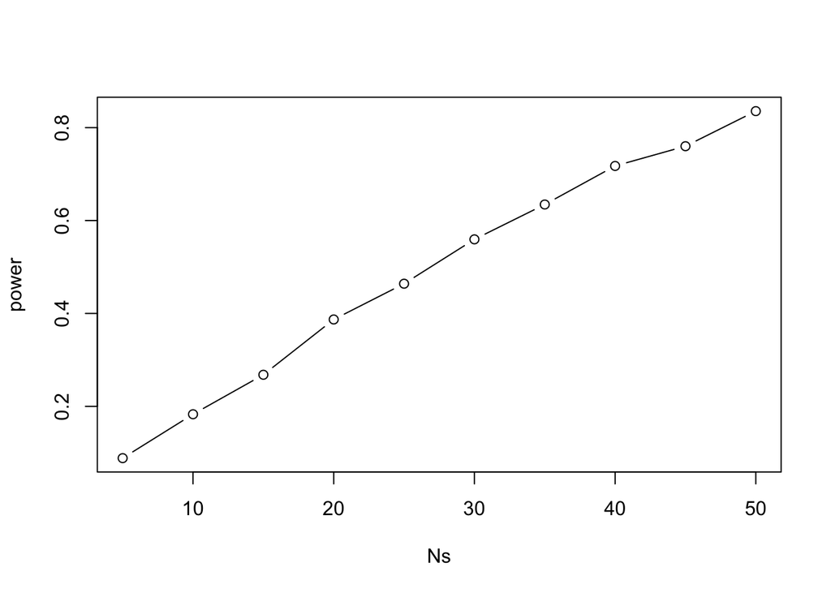

```r
plot(Ns, power, type="b")
```

Similarly if we change the level `alpha` at which we reject, power changes. The smaller I want the chance of type I error to be, the less power I will have. We can see this by writing similar code but keeping $N$ fixed and considering several values of `alpha`

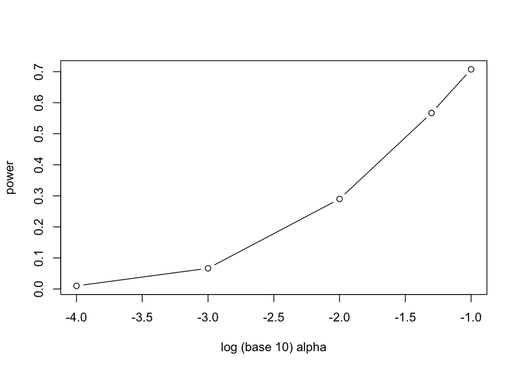

```r
N <- 30
alphas <- c(0.1,0.05,0.01,0.001,0.0001)
power <- sapply(alphas,function(alpha){
  rejections <- replicate(B,reject(N,alpha=alpha))
  mean(rejections)
})
plot(log10(alphas), power, xlab="log (base 10) alpha", type="b")
```

Note that there is no “right”" power or “right” alpha level. But it is important that you understand what each means.

**Optional homework** Create a plot with curves of power versus N. Show several curves in the same plot with color representing alpha level.